# Mise à niveau R

07 septembre 2022

## Installation

## R doit être installé proprement

```r
version$version.string
```

```
## [1] "R version 4.2.1 (2022-06-23)"
```

Mettre à jour RStudio à chaque mise à jour de R

Référence : Travailler avec R, [chapitre 1](https://ericmarcon.github.io/travailleR/chap-logiciels.html)

## Choisir un dossier de travail

Le dossier Home : `~`

Toujours travailler dans un projet : File / New Project…

Ne jamais utiliser `setwd()` pour définir le dossier de travail : c’est toujours celui du projet.

## Packages

Les packages étendent les possibilités de R.

Installation depuis un dépôt officiel avec contrôle de qualité : CRAN.

Menu Tools / Install Packages…

Les packages sont installés dans `%localappdata%/R/win-library/4.2/` pour R version 4.2.

## RStudio

Installer la dernière version.

Utiliser le codage UTF8 pour tous les fichiers:

- Menu “File > New File > R Script”,
- “File > Save with Encoding…”, choisir UTF8,
- Cocher “Set as default encoding for source files”,
- Enregistrer puis supprimer le fichier.

## Démarrage

## Les fenêtres de RStudio

[figure not shown]

## Travailler dans un projet

Créer un projet, y placer tous les fichiers.

Scripts dans le dossier du projet.

Données dans `data`.

## Un fichier par traitement

Ecrire un script dans un projet R, le commenter abondamment.

Utiliser dès que possible des blocs-note RMarkdown.

## Utiliser les aides

Aide des fonctions dans R.

Google.

Vignettes des packages.

## Echanger le projet complet

Pour collaborer, partager le dossier du projet.

Utiliser dès que possible GitHub.

## Données

## Les variables

Ecrire en haut à gauche.

```r
# Affectation
a <- 1
# ou encore
1 -> a
# mais éviter
a = 1
```

Exécuter (Ctrl+Entrée) : voir en bas à gauche. Environnement en haut à droite.

[figure not shown]

## R manipule des vecteurs

Plutôt que des nombres :

```r
x <- 1:5
2 * x
```

```
## [1]  2  4  6  8 10
```

```r
sqrt(x)
```

```
## [1] 1.000000 1.414214 1.732051 2.000000 2.236068
```

Introduction à R et au tidyverse, [Prise en main](https://juba.github.io/tidyverse/02-prise_en_main.html)

## Créer des vecteurs (1)

Des valeurs :

```r
(x <- 1)
```

```
## [1] 1
```

```r
(x <- c("pommes", "poires"))
```

```
## [1] "pommes" "poires"
```

```r
(x <- c(TRUE, FALSE))
```

```
## [1]  TRUE FALSE
```

## Créer des vecteurs (2)

Une séquence :

```r
(x <- 1:5)
```

```
## [1] 1 2 3 4 5
```

```r
(x <- seq(from = 1, to = 5, by = 1))
```

```
## [1] 1 2 3 4 5
```

## Créer des vecteurs (3)

Une répétition :

```r
(x <- rep(1, 5))
```

```
## [1] 1 1 1 1 1
```

```r
(x <- rep(1:2, each = 2))
```

```
## [1] 1 1 2 2
```

Utiliser systématiquement l’aide

```r
?rep
```

## Sélectionner des éléments (1)

Utiliser les crochets :

```r
x <- (1:10) * 10
x[3]
```

```
## [1] 30
```

```r
x[-5]
```

```
## [1]  10  20  30  40  60  70  80  90 100
```

Utiliser des vecteurs pour sélectionner :

```r
x[c(1, 3)]
```

```
## [1] 10 30
```

## Tester des éléments

Tirer des nombres dans une séquence, trouver lesquels sont pairs.

```r
x <- 1:100
# Échantillonnage
(y <- sample(x, 5))
```

```
## [1] 91 16 67 14 18
```

```r
(y%%2 == 0)
```

```
## [1] FALSE  TRUE FALSE  TRUE  TRUE
```

## Sélectionner des éléments (2)

Utiliser les crochets :

```r
y[y%%2 == 0]
```

```
## [1] 16 14 18
```

Les compter :

```r
sum(y%%2 == 0)
```

```
## [1] 3
```

## Modes

Les vecteurs contiennent des données de même mode :

- numérique : `1:2`, `1L` (L pour un entier)
- imaginaire : `(1+1i)*(1-1i)` égale 2
- logique : `TRUE`
- caractère : `"Bonjour"`
- vide : `NULL`

## Matrices

Les matrices ont deux dimensions et contiennent des données de même mode

```r
(A <- matrix(1:9, nrow = 3))
```

```
##      [,1] [,2] [,3]
## [1,]    1    4    7
## [2,]    2    5    8
## [3,]    3    6    9
```

## Sélectionner dans une matrice

```r
A[1, 2]
```

```
## [1] 4
```

```r
A[, 3]
```

```
## [1] 7 8 9
```

## Tableaux

Extension des matrices à plus de deux dimensions

```r
A <- array(1:18, dim = c(3, 3, 2))
A
```

```
## , , 1
##
##      [,1] [,2] [,3]
## [1,]    1    4    7
## [2,]    2    5    8
## [3,]    3    6    9
##
## , , 2
##
##      [,1] [,2] [,3]
## [1,]   10   13   16
## [2,]   11   14   17
## [3,]   12   15   18
```

## Sélectionner dans un tableau

Comme dans une matrice :

```r
A[, , 2]
```

```
##      [,1] [,2] [,3]
## [1,]   10   13   16
## [2,]   11   14   17
## [3,]   12   15   18
```

## Listes

Eléments disparates :

```r
(L <- list(noms = c("X", "Y"), tailles = c(100, 120)))
```

```
## $noms
## [1] "X" "Y"
##
## $tailles
## [1] 100 120
```

## Sélectionner dans une liste

Double crochet ou nom :

```r
L[[2]]
```

```
## [1] 100 120
```

```r
L$noms
```

```
## [1] "X" "Y"
```

## Dataframe

Tableau dont chaque colonne est de mode unique :

```r
(df <- data.frame(nom = c("X", "Y"), taille = c(100,
    120)))
```

```
##   nom taille
## 1   X    100
## 2   Y    120
```

## Sélectionner dans un dataframe (1)

Sélection comme dans une matrice…

```r
df[2, ]
```

```
##   nom taille
## 2   Y    120
```

… ou comme dans une liste

```r
df$taille
```

```
## [1] 100 120
```

## Sélectionner dans un dataframe (2)

Sélection de lignes en fonction de valeurs

```r
df[df$taille == 100, ]
```

```
##   nom taille
## 1   X    100
```

## Fonctions

## Définition

R est un langage fonctionnel.

```r
y <- cos(pi)
```

Une fonction produit une valeur à partir d’arguments.

## Effets de bord

Une fonction peut avoir des effets de bord :

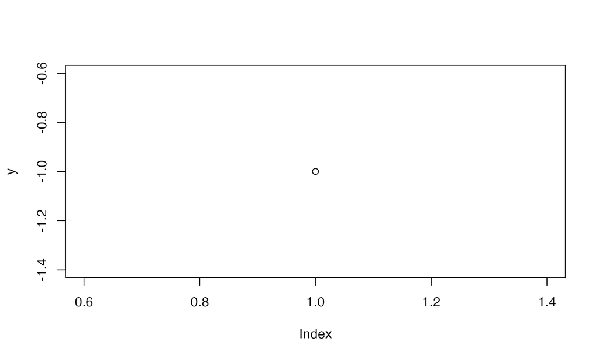

```r
x <- plot(y)
```

```r
x
```

`plot` n’est utilisé que pour ses effets de bord.

## Arguments

Appeler une fonction en nommant tous ses arguments…

```r
runif(n = 3, min = 0, max = 1)
```

```
## [1] 0.10293624 0.02248227 0.91641919
```

… ou en les passant dans l’ordre :

```r
runif(3, 0, 1)
```

```
## [1] 0.9096517 0.1370688 0.3397247
```

## Arguments nommés

Bonne pratique : nommer tous les arguments à partir du deuxième:

```r
runif(3, min = 0, max = 1)
```

```
## [1] 0.1005619 0.4669571 0.4286474
```

## Valeurs par défaut

Voir l’aide de la fonction : `?runif`

`min` et `max` ont des valeurs par défaut : 0 et 1.

```r
runif(3)
```

```
## [1] 0.53216272 0.09179518 0.02105684
```

## Créer

Syntaxe:

```r
puissance <- function(x, r = 1) {
    return(x^r)
}
puissance(1:3, r = 2)
```

```
## [1] 1 4 9
```

Penser vecteur. `r` est recyclé.

```r
puissance(1:3, r = 3:1)
```

```
## [1] 1 4 3
```

## Structures de contrôle

## Si / Sinon

```r
est_pair <- function(x) {
    if (x%%2 == 0) {
        return(TRUE)
    } else {
        return(FALSE)
    }
}
est_pair(3)
```

```
## [1] FALSE
```

Fonction non vectorielle. Utiliser plutôt :

```r
((1:3)%%2) == 0
```

```
## [1] FALSE  TRUE FALSE
```

## Boucles

```r
for (i in 1:3) {
    print(sqrt(i))
}
```

```
## [1] 1
## [1] 1.414214
## [1] 1.732051
```

Seulement si la fonction utilisée n’est pas vectorielle.

```r
sqrt(1:3)
```

```
## [1] 1.000000 1.414214 1.732051
```

## Graphiques de base

## plot

Graphiques simples :

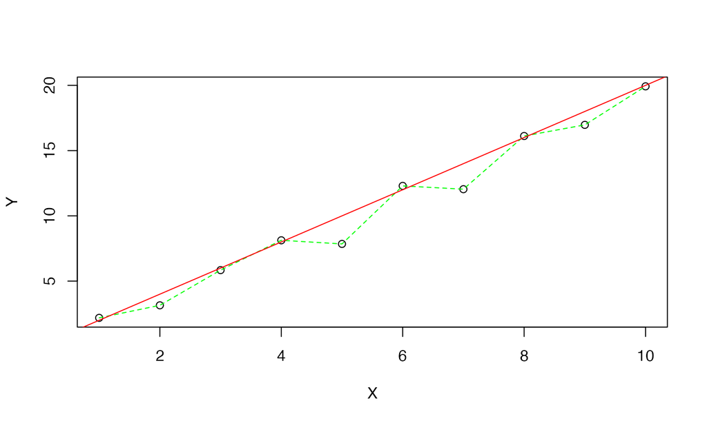

```r
X <- 1:10
Y <- 2 * X + rnorm(length(X))
plot(x = X, y = Y)
lines(x = X, y = Y, col = "green", lty = 2)
abline(a = 0, b = 2, col = "red")
```

## Classes (1)

Les objets appartiennent à des classes.

```r
Ns <- rlnorm(100)
class(Ns)
```

```
## [1] "numeric"
```

`plot` est une méthode, déclinée par classe.

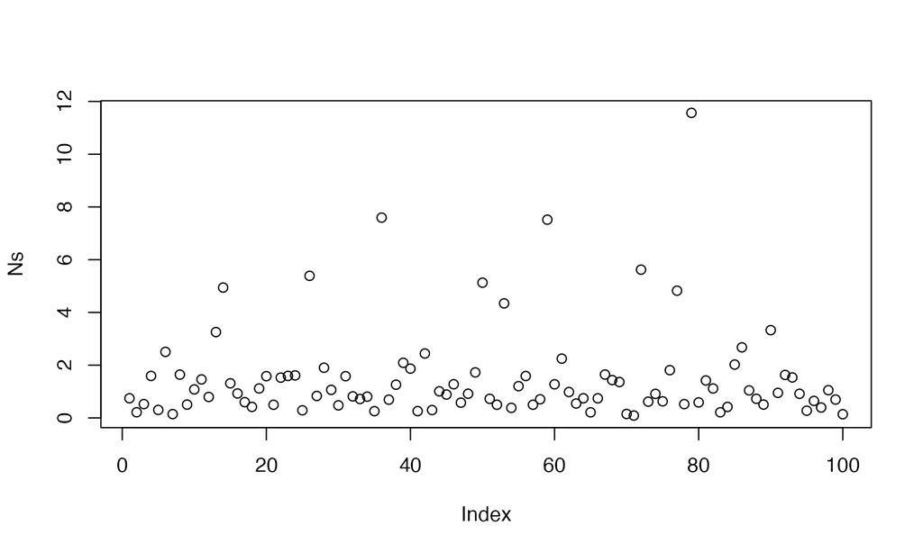

```r
plot(Ns)  # plot.numeric()
```

## Classes (2)

```r
library("entropart")
Ns <- as.AbdVector(Ns)
class(Ns)
```

```
## [1] "AbdVector"           "SpeciesDistribution"
## [3] "integer"
```

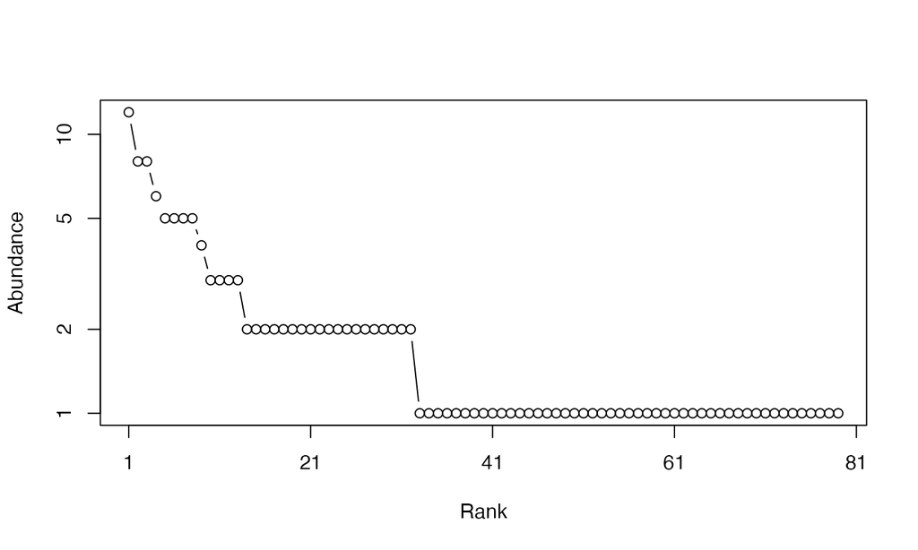

```r
plot(Ns)  # plot.SpeciesDistribution
```

## Tidyverse

## Manifeste

Univers bien rangé.

Extension de R : ensemble de packages

```r
library("tidyverse")
```

Manifeste

```r
vignette("manifesto")
```

Introduction à R et au tidyverse, [Le tidyverse](https://juba.github.io/tidyverse/06-tidyverse.html)

## Données

Autant que possible dans un dataframe.

`tibble` : dataframe amélioré.

```r
(mon_tibble <- tibble(nom = c("X", "Y"), taille = c(100,
    120)))
```

```
## # A tibble: 2 × 2
##   nom   taille
##   <chr>  <dbl>
## 1 X        100
## 2 Y        120
```

## Tuyau

Le résultat d’une fonction est le premier argument de la fonction suivante.

```r
x <- runif(100, max = 10) %>%
    mean()
x
```

```
## [1] 4.847069
```

```r
# ou même
100 %>%
    runif(max = 10) %>%
    mean() %>%
    print() -> x
```

```
## [1] 5.18077
```

## Bagarre (1)

*Data wrangling* : lecture des données dans un tibble, sélection des lignes et colonnes, création de colonnes…

```r
# Lecture des arbres de la parcelle 6 de Paracou
read_csv2("data/Paracou6.csv") %>%
  # Ne garder que les fabaceae
  filter(Family == "Fabaceae") %>%
  # Sélectionner les colonnes espèce et circonférence
  select(spName, CircCorr) %>%
  # Calculer la surface terrière de chaque arbre en m2
  mutate(G = CircCorr^2/4/pi/10000) %>%
  # Grouper par espèce
  group_by(spName) %>%
  # Calculer le nombre de tiges et la surface terrière par ha
  summarize(Abondance=n(), Surface=sum(G)/6.25 , .groups='drop') %>%
  # Trier par G/ha décroissant
  arrange(desc(Surface)) ->
  mon_tibble
```

## Bagarre (2)

Travail fastidieux :

- prévoir du temps
- capitaliser.

```r
mon_tibble
```

```
## # A tibble: 46 × 3
##   spName                 Abondance Surface
##   <chr>                      <int>   <dbl>
## 1 Eperua_falcata               266   5.68
## 2 Eperua_grandiflora            67   1.50
## 3 Vouacapoua_americana          91   1.44
## 4 Dicorynia_guianensis          44   0.762
## 5 Recordoxylon_speciosum        31   0.438
## # … with 41 more rows
```

## Graphiques avec ggplot

## ggplot2

Package destiné à la création de graphiques.

Respecte la [grammaire graphique par couches](http://vita.had.co.nz/papers/layered-grammar.pdf) :

```
ggplot(data = <DATA>) +
  <GEOM_FUNCTION>(
     mapping = aes(<MAPPINGS>),
     stat = <STAT>,
     position = <POSITION>
  ) +
  <COORDINATE_FUNCTION> +
  <FACET_FUNCTION>
```

Les données sont obligatoirement un dataframe (un tibble est un dataframe).

## Esthétique

L’esthétique désigne ce qui est représenté :

- `x` et `y` (ou `fill` pour un histogramme…)
- transparence, couleur, type de courbe, taille… : voir l’aide de chaque `geom_`.

Fonction `aes()` à plusieurs niveaux :

- argument `mapping` de `ggplot()`, hérité par les couches (`geom_`)
- ou argument `mapping` de chaque couche.

## Géométrie

La géométrie est définie par une fonction `geom_xxx` et une esthétique (ce qui est représenté).

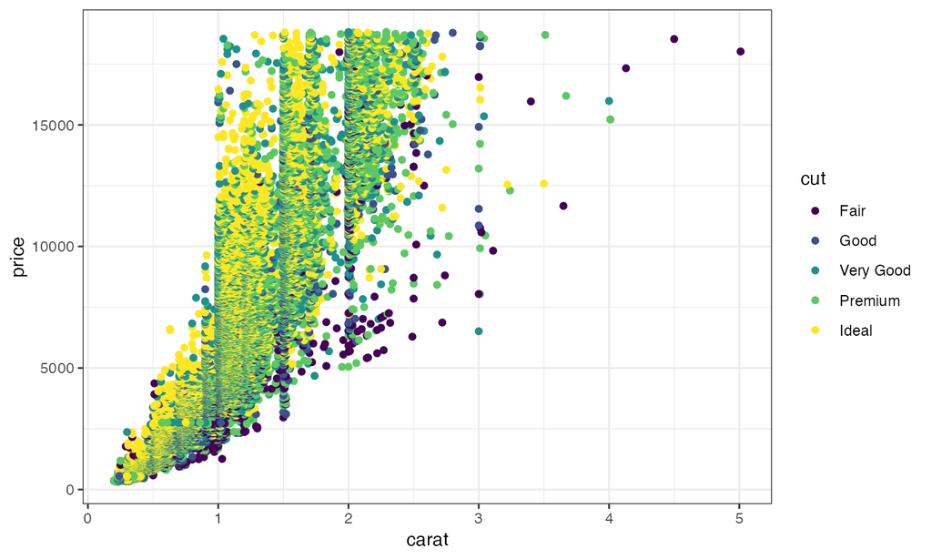

```r
ggplot(data = diamonds) +
  geom_point(mapping = aes(x = carat, y = price, color = cut))
```

## Statistiques (1)

Chaque `geom_` va de pair avec une statistique de transformation des données :

- “identity” pour `geom_point`
- “boxplot” pour `geom_boxplot`
- 20 statistiques disponibles…

## Statistiques (2)

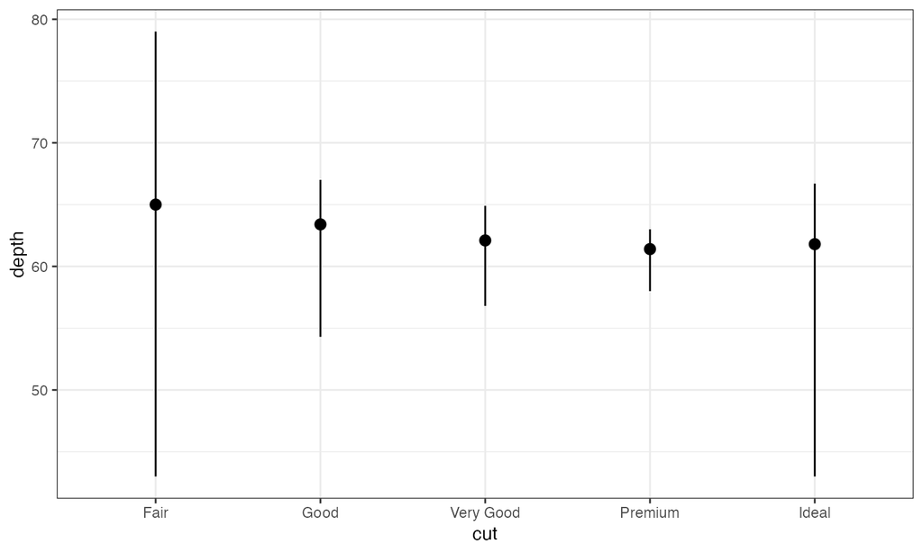

```r
ggplot(data = diamonds) +
  stat_summary(
    mapping = aes(x = cut, y = depth),
    fun.min = min,
    fun.max = max,
    fun = median
  )
```

## Echelle

Transformation de variable.

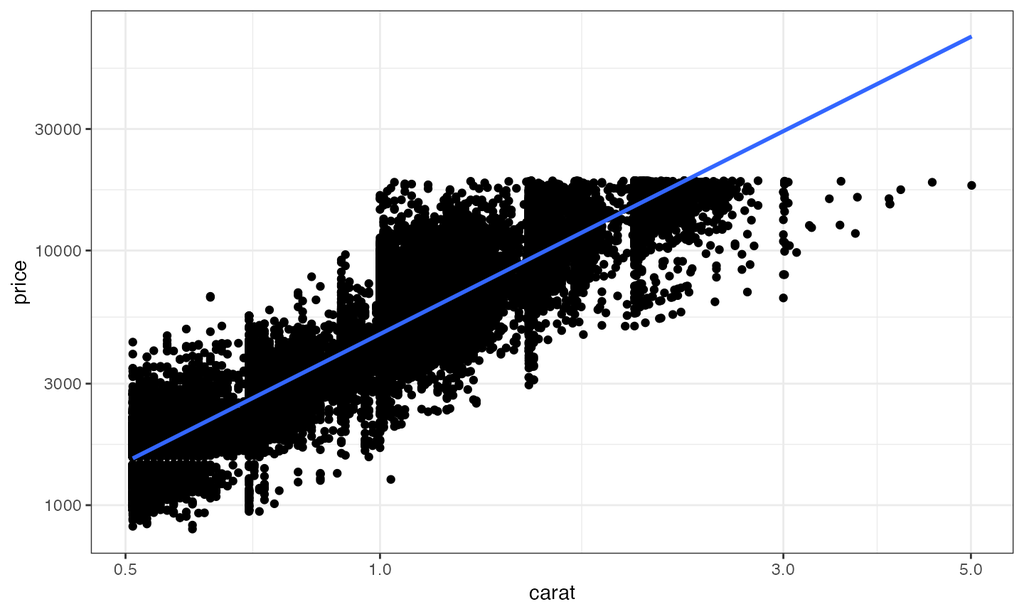

```r
diamonds %>%
    filter(carat > 0.5) %>%
    ggplot(aes(x = carat, y = price)) + geom_point() +
    scale_x_log10() + scale_y_log10() + geom_smooth(method = "lm")
```

## Position (1)

La position définit l’emplacement des objets sur le graphique.

- “identity” en général,
- “stack” empile les catégories dans un histogramme,
- “jitter” déplace aléatoirement les points dans un `geom_point` pour éviter les superpositions.

## Position (2)

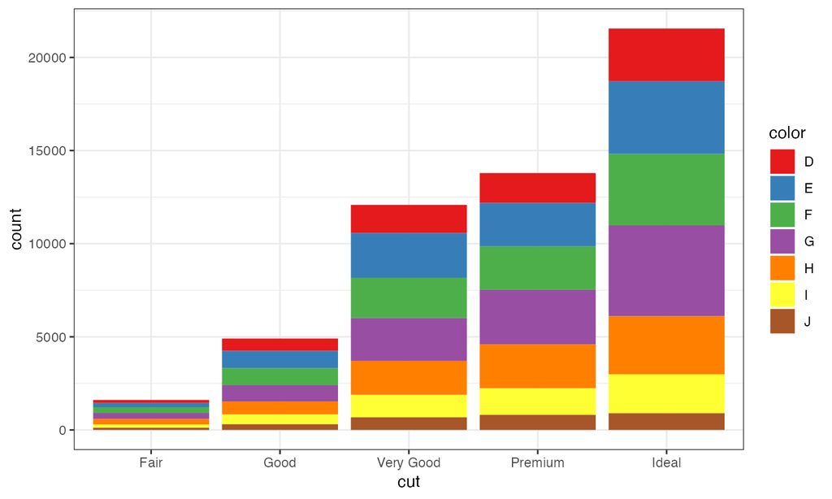

```r
ggplot(data = diamonds) +
  geom_bar(mapping = aes(x = cut, fill = color), position="stack") +
  scale_fill_brewer(palette = "Set1")
```

## Coordonnées (1)

Système de coordonnées :

- `coord_flip()` intervertit `x` et `y`,
- `coord_polar()` : coordonnées polaires,
- `coord_trans()` transforme l’affichage des coordonnées (mais pas les données comme `scale_`),
- etc.

Exemple : tracer la carte des wapas de la parcelle 6.

## Coordonnées (2)

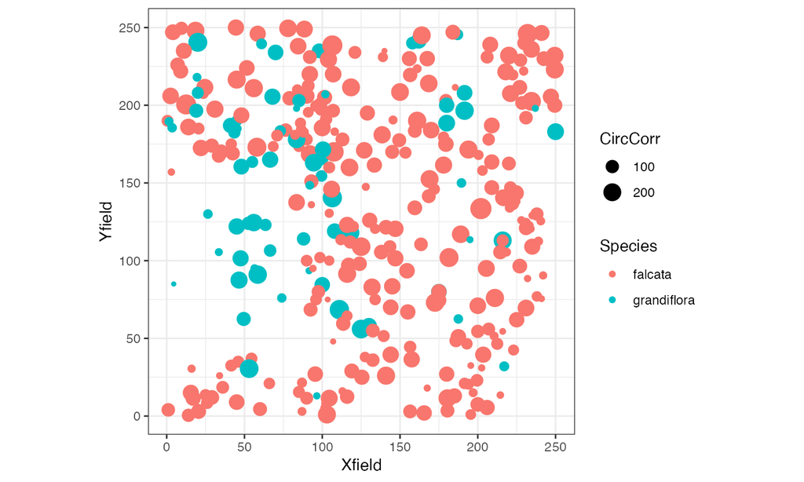

```r
read_csv2("data/Paracou6.csv") %>%
    filter(Genus == "Eperua") %>%
    ggplot() + geom_point(aes(x = Xfield, y = Yfield,
    size = CircCorr, color = Species)) + coord_fixed() ->
    P6Map
P6Map
```

## Facettes

Présente plusieurs aspects du même graphique:

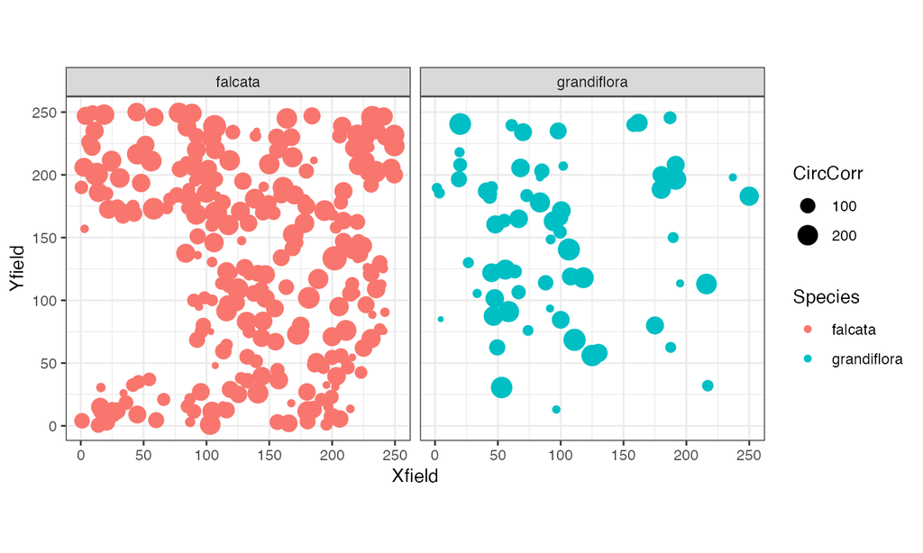

```r
P6Map + facet_wrap(~Species)
```

Possibilité d’affiner un graphique

## Aller plus loin

## Rédiger avec RMarkdown

Plutôt qu’un code commenté, un texte avec du code.

Tricot : production de documents HTML ou PDF.

Rédaction d’articles, de mémoires, de diaporama.

Reproductibilité : le projet contient les données, le code, le texte et le modèle de mise en forme.

Galerie : https://ericmarcon.github.io/memoiR/

## Contrôle de source

git (contrôle de source) et GitHub (plateforme web) pour :

- tracer les versions d’un projet,
- collaborer,
- tester le code automatiquement,
- tricoter automatiquement.

Exemple: https://github.com/EricMarcon/travailleR

## Sites web etc.

Il existe des packages pour tout.

Exemples :

- Site web : https://ericmarcon.github.io/,
- Application Shiny : https://vac-lshtm.shinyapps.io/ncov_tracker/,
- TP en ligne : https://eric-marcon.shinyapps.io/TP-Biodiversite/.